# Mixed models 2

Timothee Bonnet

13 May 2020

**Today we learn:**

- Interpreting and visualizing mixed-effect models
- Measuring the uncertainty in a random effect parameter
- (Should you treat “Year” as a fixed or random effect?)

Load packages for today:

```r
library(lmerTest)
```

```r
library(ggplot2)
```

Load data:

```r
download.file("https://timotheenivalis.github.io/data/thorndata.csv",
              destfile = "data/thorndata.csv")

download.file("https://timotheenivalis.github.io/data/droughtdata.csv",
                        destfile = "data/droughtdata.csv")

download.file("https://timotheenivalis.github.io/data/roo.csv",
                        destfile = "data/roo.csv")

download.file("https://timotheenivalis.github.io/data/storks.csv",
                        destfile = "data/storks.csv")
```

## Visualize

We model the relationship EscapeDistance / Tail_Length.

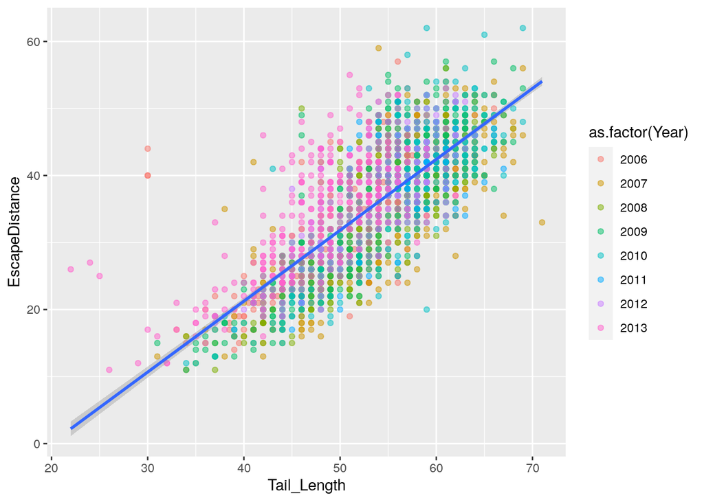

```r
roo <- read.csv("data/roo.csv")

ggplot(roo, aes(x=Tail_Length, y=EscapeDistance)) +
  geom_point(aes(color=as.factor(Year)), alpha=0.5) +
  geom_smooth(method = "lm")
```

```r
mm0 <- lmer(EscapeDistance ~ Tail_Length + (1|Year), data = roo)
summary(mm0)
```

```
## Linear mixed model fit by REML. t-tests use Satterthwaite's method [
## lmerModLmerTest]
## Formula: EscapeDistance ~ Tail_Length + (1 | Year)
##    Data: roo
##
## REML criterion at convergence: 15630
##
## Scaled residuals:
##     Min      1Q  Median      3Q     Max
## -3.6300 -0.6676 -0.0983  0.5826  6.0700
##
## Random effects:
##  Groups   Name        Variance Std.Dev.
##  Year     (Intercept)  4.108   2.027
##  Residual             33.561   5.793
## Number of obs: 2456, groups:  Year, 8
##
## Fixed effects:
##               Estimate Std. Error         df t value Pr(>|t|)
## (Intercept)  -25.52373    1.18717   48.52328  -21.50   <2e-16 ***
## Tail_Length    1.14330    0.01763 2451.96379   64.85   <2e-16 ***
## ---
## Signif. codes:  0 '***' 0.001 '**' 0.01 '*' 0.05 '.' 0.1 ' ' 1
##
## Correlation of Fixed Effects:
##             (Intr)
## Tail_Length -0.789
```

```r
# Fixed effects:
fixef(mm0)
```

```
## (Intercept) Tail_Length
##  -25.523733    1.143302
```

```r
# Random deviations (a.k.a. "random predictions"):
ranef(mm0)
```

```
## $Year
##      (Intercept)
## 2006  0.05975949
## 2007 -1.62167497
## 2008 -2.07637086
## 2009  0.45260470
## 2010 -1.07825970
## 2011 -1.09178499
## 2012  1.27687634
## 2013  4.07885000
##
## with conditional variances for "Year"
```

```r
# Fixed effects plus random deviations:
coef(mm0)
```

```
## $Year
##      (Intercept) Tail_Length
## 2006   -25.46397    1.143302
## 2007   -27.14541    1.143302
## 2008   -27.60010    1.143302
## 2009   -25.07113    1.143302
## 2010   -26.60199    1.143302
## 2011   -26.61552    1.143302
## 2012   -24.24686    1.143302
## 2013   -21.44488    1.143302
##
## attr(,"class")
## [1] "coef.mer"
```

```r
#Random effect variance components
as.numeric(VarCorr(mm0))
```

```
## [1] 4.108495
```

Visualize the year slope predictions:

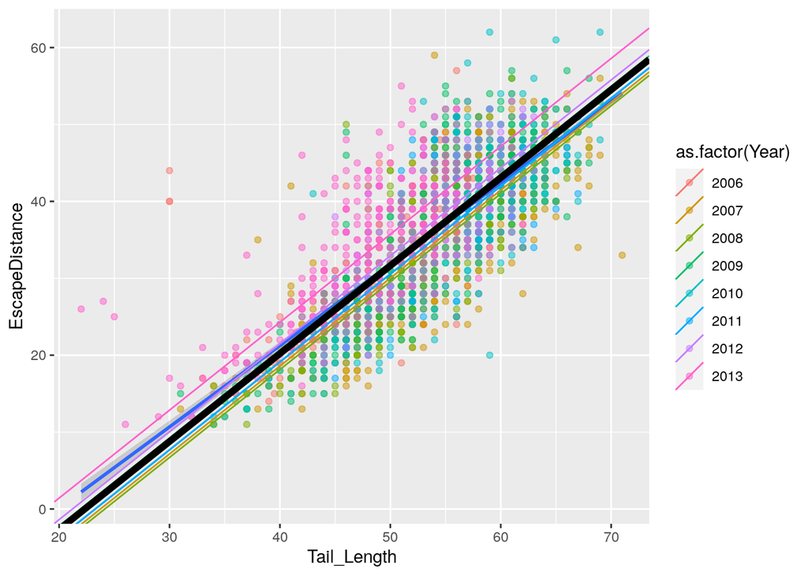

```r
predlm <- as.data.frame(coef( mm0 )$Year)
predlm$Year <- rownames(predlm)
mainslope <- as.data.frame(t(fixef(mm0)))

ggplot(roo, aes(x=Tail_Length, y=EscapeDistance)) +
  geom_point(aes(color=as.factor(Year)), alpha=0.5) +
  geom_smooth(method = "lm")+
  geom_abline(inherit.aes = FALSE,
              data = predlm,
              aes(intercept=`(Intercept)`,
                  slope=Tail_Length,
                  color=as.factor(Year))) +
  geom_abline(inherit.aes = FALSE,
              data = mainslope,
              aes(intercept=`(Intercept)`,
                  slope=Tail_Length), size=2)
```

Visualize the distribution of year effects and where to expect new years:

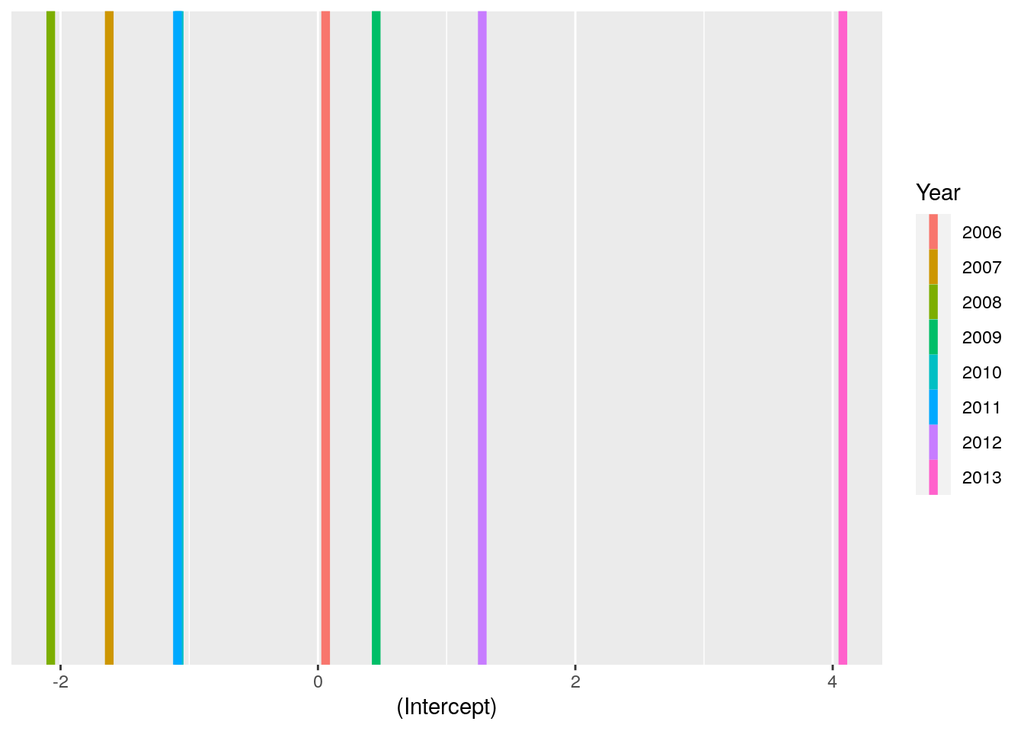

```r
yeardeviations <- as.data.frame(ranef(mm0)$Year)
yeardeviations$Year <- row.names(yeardeviations)

ggplot(yeardeviations, aes(x=`(Intercept)`, color=Year)) +
  geom_vline(aes(xintercept=`(Intercept)`, color=Year), size=2)
```

```r
as.numeric(VarCorr(mm0))
```

```
## [1] 4.108495
```

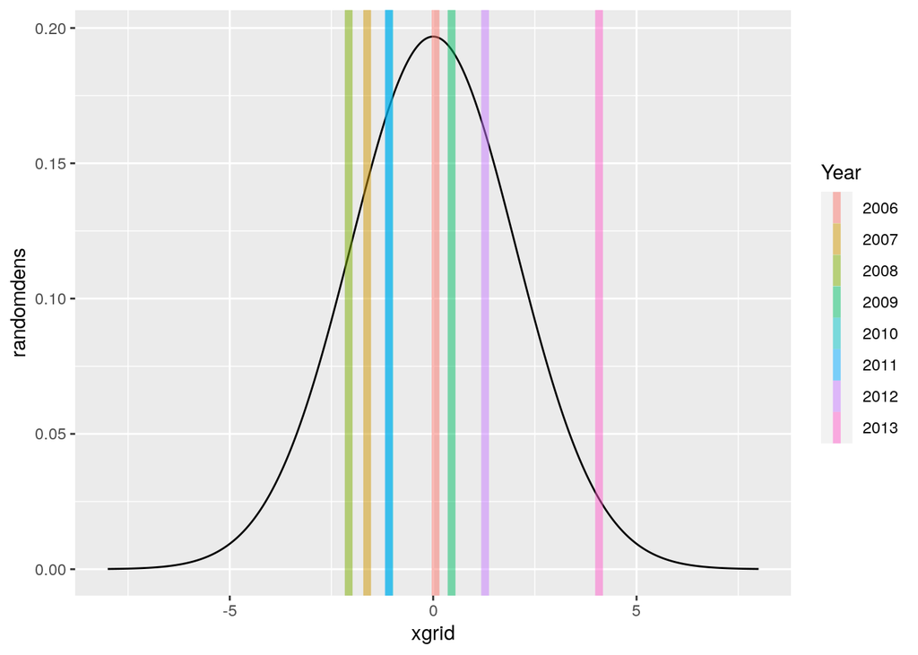

```r
xgrid <- seq(-8,8, by = 0.01)
randomdens <- dnorm(x = xgrid, mean = 0, sd = sqrt(as.numeric(VarCorr(mm0))))
REdensity <- data.frame(xgrid=xgrid, randomdens=randomdens)

ggplot(REdensity, aes(x=xgrid, y=randomdens)) + geom_line()+
  geom_vline(data= yeardeviations,
             aes(xintercept=`(Intercept)`, color=Year), size=2, alpha=0.5)
```

Visualize the projected range of observed and unobserved years around linear regression:

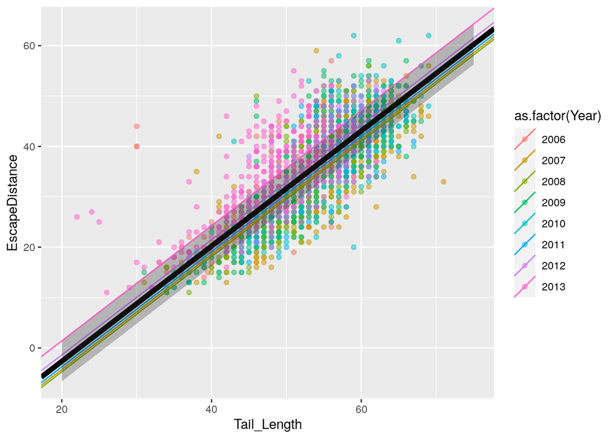

```r
Int_low95 <- fixef(mm0)["(Intercept)"] - 1.96 * sqrt(as.numeric(VarCorr(mm0)))
Int_upp95 <- fixef(mm0)["(Intercept)"] + 1.96 * sqrt(as.numeric(VarCorr(mm0)))

Tail_Length <- seq(20,75, by = 1)


intervalRE <- data.frame(Tail_Length=Tail_Length,
                         low95 =  Int_low95 + fixef(mm0)["Tail_Length"]*Tail_Length,
                         upp95 = Int_upp95 + fixef(mm0)["Tail_Length"]*Tail_Length)

ggplot(roo, aes(x=Tail_Length, y=EscapeDistance)) +
  geom_point(aes(color=as.factor(Year)), alpha=0.5) +
  geom_abline(inherit.aes = FALSE,
              data = predlm,
              aes(intercept=`(Intercept)`,
                  slope=Tail_Length,
                  color=as.factor(Year))) +
  geom_abline(inherit.aes = FALSE,
              data = mainslope,
              aes(intercept=`(Intercept)`,
                  slope=Tail_Length), size=2) +
  geom_ribbon(inherit.aes = FALSE,
                data=intervalRE,
                aes(x=Tail_Length,ymin=low95, ymax=upp95), alpha=0.3)
```